# Telecom Churn Case Study_COMMENTS

### INTERPRETABLE MODELS

#### LOGISTIC REGRESSION MODELS

#### Logistic Regression with penanlty 12 - RECALL 27%

```
           precision    recall  f1-score   support

       0       0.94      0.99      0.96      8250
       1       0.67      0.27      0.38       735
```

Accuracy of LR classifier on training set: 0.934984

Accuracy of LR classifier on test set: 0.929104

[[8151 99] [ 538 197]]

#### Logistic Regression with class_weight of "balanced" - RECALL - 81%

THIS IS A GOOD MODEL WITH A RECALL RATE OF 81 %

```
           precision    recall  f1-score   support

       0       0.98      0.83      0.90      8250
       1       0.30      0.81      0.43       735
```

Accuracy of LR classifier on training set: 0.826560

Accuracy of LR classifier on test set: 0.825710

[[6820 1430] [ 136 599]]

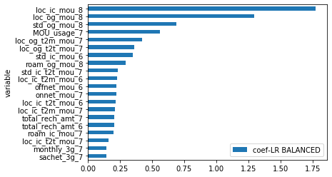

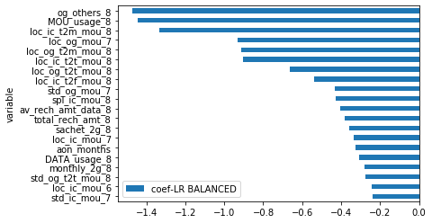

### Logistic Regression with class_weight of " {0: .09, 1: 0.95}"

THIS IS A GOOD MODEL WITH A RECALL RATE OF 81 %

```
           precision    recall  f1-score   support

       0       0.98      0.83      0.90      8250
       1       0.30      0.81      0.44       735
```

Accuracy of LR classifier on training set: 0.834574 Accuracy of LR classifier on test set: 0.830829

[[6867 1383] [ 137 598]]

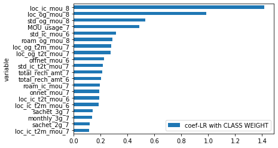

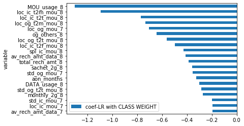

*TOP 15 RFE COLUMNS of best LOGISTIC REGRESSION MODEL*

'loc_og_t2t_mou_8', 'loc_og_t2m_mou_8', 'loc_og_mou_7', 'loc_og_mou_8', 'std_og_mou_7', 'std_og_mou_8', 'og_others_8', 'loc_ic_t2t_mou_8', 'loc_ic_t2m_mou_8', 'loc_ic_t2f_mou_8', 'loc_ic_mou_8', 'spl_ic_mou_8', 'av_rech_amt_data_8', 'MOU_usage_7', 'MOU_usage_8'

### SVM without smote ON BOTH KERNELS

ALL SVM MODELS ARE EXTREMELY INACCURATE WE WIL NOT BE CONSIDERING THE RECOMMENDED PARAMETERS SINCE RECALL IS EXTREMELY LOW

*** 1) RBF KERNEL accuracy: 0.9287701725097385

[[8174 76] [ 564 171]]

*** 2) LINEAR KERNEL accuracy: 0.9236505286588759

[[8235 15] [ 671 64]]

### RANDOM FORESTS WITH SMOTE

#### 1 ) PLAIN RANDOM FOREST NO SMOTE - LOW RECALL

[[8200 50] [ 664 71]]

#### 2 ) PLAIN RANDOM FOREST WITH SMOTE - RESONABLE RECALL 67%

```
            precision    recall  f1-score   support

       0       0.97      0.92      0.94      8250
       1       0.43      0.67      0.53       735
```

#### 3) random forest hyper parameter tuning 'min_samples_leaf' with smote - RECALL 79%

```
          precision    recall  f1-score   support

       0       0.98      0.88      0.93      8250
       1       0.36      0.79      0.50       735
```

#### 4) random forest hyper parameter tuning 'max_depth' - RECALL 70%

```
          precision    recall  f1-score   support

       0       0.97      0.92      0.94      8250
       1       0.42      0.70      0.53       735
```

#### 5) random forest hyper parameter tuning 'n_estimators' with smote - RECALL 72%

```
          precision    recall  f1-score   support

       0       0.97      0.92      0.95      8250
       1       0.44      0.72      0.55       735
```

#### 6) Random forest parameters after hyper tuning with SMOTE - recall 80%

```
          precision    recall  f1-score   support

       0       0.98      0.87      0.92      8250
       1       0.36      0.80      0.50       735
```

*** RECOMMENDED PARAMETERS RANDOM FOREST AFTER HYPER PARAMETER TUNING WITH SMOTE

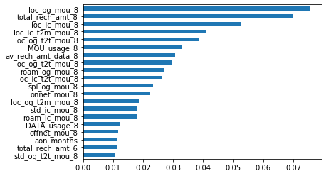

NEGATIVE INFLUENCERS

1) og_others_8 2) mou_usage_8 3) loc_ic_t2m_mou_8 4) loc_ic_t2t_mou_8 5) loc_og_t2m_mou_8

## RECOMMENDATIONS

1) THE COMPANY IS CLEARLY WATCH ALL 8TH MONTH DATA. WE SEE MOST INFLUENCING PARAMETERS ARE OF THE 8TH MONTH THIS IS CONSISTENT WITH OUR EDA AND PCA CLUSTERING FINDINGS.

2) DROP IN CALL LOCAL MOU IN THE 8TH MONTH CONTRUBUTES TO CHURH - LOCAL IC AND OUTGOING MOU ARE HIGHLY CORELLATED WITH CUSTOMER RETENTION. THE COMPANY SHOULD STUDY WEEKLY MARKERS AND TARGET CUSTOMERS BY MID 8TH MONTH TO TRY TO RETAIN THEM. THIS MEANS CUSTOMER IS NO LONGER ACTIVELY USING THE CONNECTION IF HIS OCAL CALLS REDUCE.

3) INTERESTINGLY CUSTOMER TO OPERATOR CALLS PARAMETER IS A NEGATIVE CONTRIBUTOR. WHICH PROBABLY MEANS SOME UNRESOLVED CUSTOMER ISSUE.PAY ATTENTION TO SUCH CALLS

4) MOU USAGE IN THE 8TH MONTH REDUCES MORE THEN CUSTOMER IS LIKELY TO CHURN.

5) AVERAGE RECHARGE AMT AND TOTAL RECHARGE AMOUNT REDUCE IF CUSTOMER IS LIKELY TO CHURN.

6) IF CUSTOMER HAS ROAMING CALLS MAY BE HE IS USING THIS NUMBER LESS BUT STILL WISHES TO RETAIN.HE MAKES OG CALLS.

THE KEY IS TO STUDY THE DIFFERENCE BETWEEN USAGE OF 7TH AND 8TH MONTH. PATTERN DIFFERENCES IN MOU , DATA AND THEREFORE REVENUE GIVE US A CLUE ON WHAT TO TARGET.

7) INTERESTINGLY FB USERS PAID HIGH THE HIGHEST AVG RECHARGE AMOUNTS.WE CAN TARGET SUCH SOCIAL MEDIA OFFERINGS